# Business Inquiry to Research Solution

Author: Jesus Cantu Jr

4/14/23

# Business Objective:

This exercise asks you to help a hypothetical agency partner discover and describe patterns in takeup of a benefit while exploring the possibility of a future randomized trial. Suppose our partners have two administrative datasets related to small businesses that were eligible to receive federal aid. One contains the email address of the business owner along with owner-reported details about their business. The other contains information unique to the ZIP code in which a business is located. All owners were notified of their eligibility for aid but not all applied for funding. Our agency partners have two goals:

1. Identifying Application Rates: First, our partners would like a better understanding of the types of businesses from this sample that did and did not submit an application. Identify the two or three most salient ways that applicant and non-applicant businesses differ, paying particular attention to whether there are specific business types that apply at higher or lower rates than others. You may assume the businesses listed in the sample are a comprehensive list of all eligible businesses.
2. Increasing Application Rates: Second, our partners would like to explore the possibility of a future randomized trial estimating the effect of mailers (e.g. informational brochures about the program sent to potential applicants) on application rates. They would like to be able to know whether the outreach program was effective at increasing application rates overall, and ideally whether it was effective for business owners who were least likely to apply in the initial round.

The agency partner is relying on our expertise to recommend whether a randomized trial that can answer these questions is feasible. They have told us that mailing costs are not a concern, as they have already decided to conduct mail outreach in some form. Your role is to advise whether or not an RCT that answers their questions seems sufficiently well-powered, and if so, how it should be designed.

# Data Description:

The data sets we received from our partners are named business_data.csv and zip_data.csv. The first contains a number of variables at the business-level:

- applied: a binary indicator for whether a small business owner applied for aid;
- FTE: number of full-time equivalent employees;
- MOB: indicator for whether the business is minority-owned;
- WOB: indicator for whether the business is woman-owned;
- FY19: reported revenue in the 2019 fiscal year;
- FY20: reported revenue in the 2020 fiscal year;
- email: the email address of the business owner;
- zip_id: the ZIP code of the business.

The second contains info at the ZIP code level:

- zipCode: the ZIP codes in the county of interest;
- size: the population within the zip code;
- status: the urban/rural status of the zip code.

```r
# Load the necessary packages
library(dplyr)
library(ggplot2)
library(tidyr)

# Set working directory
setwd("/Users/Jesse/Desktop/MacBookAir/OES")

# Read in the data
business_data <- read.csv("business_data.csv")
zip_data <- read.csv("zip_data.csv")
```

# Data Wrangling:

```r
# Explore business data set structure & missing values:
dim(business_data) # dimensions
```

```
## [1] 8139    8
```

```r
summary(business_data) # Summary of the distribution of variables
```

```
##     zip_id             email                MOB              WOB
##  Length:8139        Length:8139        Min.   :0.0000   Min.   :0.0000
##  Class :character   Class :character   1st Qu.:0.0000   1st Qu.:0.0000
##  Mode  :character   Mode  :character   Median :1.0000   Median :0.0000
##                                        Mean   :0.5704   Mean   :0.2259
##                                        3rd Qu.:1.0000   3rd Qu.:0.0000
##                                        Max.   :1.0000   Max.   :1.0000
##                                        NA's   :632      NA's   :618
##       FTE              FY19              FY20            applied
##  Min.   :  0.00   Min.   :  30121   Min.   :  23531   Min.   :0.0000
##  1st Qu.: 36.00   1st Qu.:  78398   1st Qu.:  67731   1st Qu.:0.0000
##  Median : 62.00   Median : 232749   Median : 200921   Median :1.0000
##  Mean   : 61.41   Mean   : 386566   Mean   : 335641   Mean   :0.5683
##  3rd Qu.: 86.00   3rd Qu.: 568812   3rd Qu.: 491124   3rd Qu.:1.0000
##  Max.   :129.00   Max.   :2437515   Max.   :2852171   Max.   :1.0000
##  NA's   :667      NA's   :674       NA's   :691
```

```r
# Count the number of missing values in the data set
num_missing <- sum(is.na(business_data))

# Print the result
cat("Total number of missing values in business data set:", num_missing, "\n")
```

```
## Total number of missing values in business data set: 3282
```

```r
# Identify rows with missing values
missing_rows <- rowSums(is.na(business_data)) > 0

# Print first 5 rows with missing values
head(business_data[missing_rows,], n = 5)
```

|  | zip_id | email | MOB | WOB | FTE | FY19 | FY20 | applied |
| --- | --- | --- | --- | --- | --- | --- | --- | --- |
| 1 | 665201 | l1bclOczoo@gmail.com | NA | 1 | 0 | 37665.26 | 28792.50 | 0 |
| 2 | 665201 | A5BJdyr7ee@gmail.com | 1 | 0 | NA | 90925.65 | NA | 1 |
| 5 | 665201 | 6AzVs4uOHz@inbox.com | 1 | 0 | 55 | NA | 136078.45 | 0 |
| 13 | 665201 | wEWoWGjsXE@outlook.com | 0 | NA | NA | 99363.90 | 97055.63 | 0 |
| 17 | 665201 | 69Dtu93zRg@inbox.com | 0 | NA | 96 | 824324.67 | 944721.30 | 0 |

Business data (i.e., ‘business_data.csv’) contains 8139 obs. and 8 columns; most columns contain missing values. There is a total of 3282 missing values in this data set. Depending on our analyses, we might have to delete them later. Notice that missing values are spread out throughout the data among the different columns; there are no rows that are completely empty.

Also note that the variable associated with zip code (i.e, ‘zip_id’) is currently being read as a character. This might have to be updated to match the other data set, if this variable is to be used for merging.

```r
# Investigate if there are any duplicate entries
any(duplicated(business_data))
```

```
## [1] TRUE
```

```r
# Sort the data frame by 'zip_id' to make them easier to spot
sorted_data <- business_data[order(business_data[, 1]), ]

# Identify duplicate rows across all columns in the data
dups <- duplicated(sorted_data[, 1:8]) | duplicated(sorted_data[, 1:8],
                                                    fromLast = TRUE)
# Count the number of duplicate rows
sum(dups)
```

```
## [1] 112
```

```r
# Display duplicate rows grouped together, first 5 rows
head(sorted_data[dups, ], n = 5)
```

|  | zip_id | email | MOB | WOB | FTE | FY19 | FY20 | applied |
| --- | --- | --- | --- | --- | --- | --- | --- | --- |
| 3 | 665201 | 6cK5zp25yM@inbox.com | 1 | 1 | 75 | 317375.20 | 247614.91 | 0 |
| 8101 | 665201 | 6cK5zp25yM@inbox.com | 1 | 1 | 75 | 317375.20 | 247614.91 | 0 |
| 135 | 665202 | ne1qhoPoy7@mail.com | 1 | 1 | 19 | 34473.82 | 30447.39 | 0 |
| 8099 | 665202 | ne1qhoPoy7@mail.com | 1 | 1 | 19 | 34473.82 | 30447.39 | 0 |
| 233 | 665203 | STgvMrbRdn@gmail.com | 0 | 0 | 30 | 67648.53 | 70797.65 | 0 |

```r
# Remove duplicates
# The unique() function is then used to remove the duplicates
# and keep only the first occurrence of each unique row
business_data <- unique(business_data)

# Check for duplicates again
any(duplicated(business_data)) # we have removed duplicate entries
```

```
## [1] FALSE
```

```r
# Explore zip code data set structure & missing values:
dim(zip_data) # dimensions
```

```
## [1] 20  4
```

```r
summary(zip_data) # Summary of the distribution of variables
```

```
##        X            zipCode            size          status
##  Min.   : 1.00   Min.   :665201   Min.   :  738   Length:20
##  1st Qu.: 5.75   1st Qu.:665206   1st Qu.: 1147   Class :character
##  Median :10.50   Median :665210   Median : 2316   Mode  :character
##  Mean   :10.50   Mean   :665210   Mean   : 4322
##  3rd Qu.:15.25   3rd Qu.:665215   3rd Qu.: 6936
##  Max.   :20.00   Max.   :665220   Max.   :12104
```

```r
# Count the number of missing values in the data set
num_missing <- sum(is.na(zip_data))

# Print the result
cat("Total number of missing values in zip code data set:", num_missing, "\n")
```

```
## Total number of missing values in zip code data set: 0
```

```r
# Drop unnecessary column from data by specifying what columns we want
zip_data = zip_data[ , c("zipCode","size", "status")]
```

Zip code data (i.e., ‘zip_data.csv’) contains 20 obs. and 4 columns; the data set does not contain any missing values. However, it seems there is an extra column ‘X’, not mentioned in the data description that have might be added earlier as an index. We will remove this column as it not needed for our analysis.

```r
# Merged data sets based on zip code attribute

# Rename 'zip_id' column in business data to match our other data set
names(business_data)[names(business_data) == "zip_id"] <- "zipCode"

# We also want to change the attribute type from string to numeric
# However, the 'ZipCode' column in the business data currently
# contains values with the following format ZipCode-0000 (e.g., 665201-0000),
# which will turn to NA's when converted to integer

# We will split the column first by hyphen
# and select the first part of the substring
business_data$zipCode <- sapply(strsplit(business_data$zipCode, "-"), "[", 1)
# Then convert string to numeric values
business_data$zipCode <- as.integer(business_data$zipCode)

# Merge the two data frames based on 'ZipCode' column
merged_data <- merge(business_data, zip_data, by = "zipCode")

# Print the result
head(merged_data)
```

|  | zipCode | email | MOB | WOB | FTE | FY19 | FY20 | applied | size | status |
| --- | --- | --- | --- | --- | --- | --- | --- | --- | --- | --- |
| 1 | 665201 | l1bclOczoo@gmail.com | NA | 1 | 0 | 37665.26 | 28792.50 | 0 | 1214 | rural |
| 2 | 665201 | A5BJdyr7ee@gmail.com | 1 | 0 | NA | 90925.65 | NA | 1 | 1214 | rural |
| 3 | 665201 | 6cK5zp25yM@inbox.com | 1 | 1 | 75 | 317375.20 | 247614.91 | 0 | 1214 | rural |
| 4 | 665201 | YqJ0LaxGWm@mail.com | 0 | 0 | 77 | 493244.56 | 511119.15 | 0 | 1214 | rural |
| 5 | 665201 | 6AzVs4uOHz@inbox.com | 1 | 0 | 55 | NA | 136078.45 | 0 | 1214 | rural |
| 6 | 665201 | YodSzjt9lf@gmail.com | 0 | 1 | 35 | 65414.38 | 60241.43 | 0 | 1214 | rural |

```r
dim(merged_data) # dimensions
```

```
## [1] 8083   10
```

```r
# Created a copy of the merged data without NA's
merged_data_clean <- na.omit(merged_data)

# Print the result
head(merged_data_clean)
```

|  | zipCode | email | MOB | WOB | FTE | FY19 | FY20 | applied | size | status |
| --- | --- | --- | --- | --- | --- | --- | --- | --- | --- | --- |
| 3 | 665201 | 6cK5zp25yM@inbox.com | 1 | 1 | 75 | 317375.20 | 247614.91 | 0 | 1214 | rural |
| 4 | 665201 | YqJ0LaxGWm@mail.com | 0 | 0 | 77 | 493244.56 | 511119.15 | 0 | 1214 | rural |
| 6 | 665201 | YodSzjt9lf@gmail.com | 0 | 1 | 35 | 65414.38 | 60241.43 | 0 | 1214 | rural |
| 7 | 665201 | QpBdrOkqK8@gmail.com | 0 | 0 | 46 | 147730.92 | 122292.13 | 1 | 1214 | rural |
| 8 | 665201 | hppFfD0Ywh@gmail.com | 1 | 0 | 65 | 242942.05 | 209709.91 | 0 | 1214 | rural |
| 9 | 665201 | BCg8kDWgpM@inbox.com | 1 | 0 | 50 | 138759.87 | 111529.12 | 0 | 1214 | rural |

```r
dim(merged_data_clean) # dimensions
```

```
## [1] 5331   10
```

```r
# Saved copy of the merged data sets as CSV files
write.csv(merged_data, file = "business_zip_data.csv",
          row.names = FALSE)
write.csv(merged_data_clean, file = "business_zip_data_clean.csv",
          row.names = FALSE)
```

For our analysis, we merged the business and zip data sets based on the column that specifies zip code. Data wrangling was done to ensure the attributes matched in terms of column name and data type, so that merging could be done correctly. A copy of the merged data was created with and without missing values. We saved these new data frames as CSV files for future use.

# Data Analysis (Identifying Application Rates):

First, our partners would like a better understanding of the types of businesses from this sample that did and did not submit an application.

We will identify the two or three most salient ways that applicant and non-applicant businesses differ, paying particular attention to whether there are specific business types that apply at higher or lower rates than others. We will assume that the businesses listed in the sample are a comprehensive list of all eligible businesses.

# 1) Hypothesis testing:

If we have a categorical variable such as business type or ownership, we can use hypothesis testing to determine whether there is a significant difference in the application rates between different groups.

For example, we can use a chi-squared test or Fisher’s exact test to compare the proportion of applicants and non-applicants in each business type or ownership group. We can set the significance level to 0.05 or 0.01, which indicates the probability of obtaining a test statistic as extreme as the observed one by chance.

```r
# Load business and zip data from CSV file
clean_data <- read.csv("business_zip_data_clean.csv")

# Note, if one or both of the vectors being used to create the contingency
# table are not of the correct variable type, this can cause the error.

# If the two vectors being used to create the contingency table
# have different factor levels, this can also cause the error.

# Ensure that both vectors have the same factor levels
clean_data <- within(clean_data, {
  applied_factor <- factor(applied)
  MOB_factor <- factor(MOB)
  WOB_factor <- factor(WOB)
  status_factor <- factor(status)
})

# Create a contingency table of applied and ownership type (minority-owned)
cont_table1 <- table(clean_data$applied, clean_data$MOB_factor)

# Conduct a chi-squared test of independence
test_result1 <- chisq.test(cont_table1)

# Print the test result
print("Results of hypothesis test: applied and ownership type (minority-owned): ")
```

```
## [1] "Results of hypothesis test: applied and ownership type (minority-owned): "
```

```r
test_result1
```

```
##
##  Pearson's Chi-squared test with Yates' continuity correction
##
## data:  cont_table1
## X-squared = 11.82, df = 1, p-value = 0.0005859
```

The Pearson’s Chi-squared test with Yates’ continuity correction was used to investigate the association between two categorical variables, applied and ownership type (minority-owned).

The test statistic is X-squared = 11.82 with df = 1 and p-value = 0.0005859 (p<0.001), indicating a significant association between the two variables. The results suggest that there is strong evidence to reject the null hypothesis of no association in favor of the alternative hypothesis that there is an association between the two categorical variables, applied and ownership type (minority-owned)

Further analysis, such as a post-hoc test or logistic regression, may be necessary to determine the nature and strength of this association.

```r
# Create a contingency table of applied and ownership type (women-owned)
cont_table2 <- table(clean_data$applied, clean_data$WOB_factor)

# Conduct a chi-squared test of independence
test_result2 <- chisq.test(cont_table2)

# Print the test result
print("The contingency table is as follows: ")
```

```
## [1] "The contingency table is as follows: "
```

```r
print(cont_table2)
```

```
##
##        0    1
##   0 1721  583
##   1 2448  579
```

```r
print("Results of hypothesis test: applied and ownership type (women-owned): ")
```

```
## [1] "Results of hypothesis test: applied and ownership type (women-owned): "
```

```r
test_result2
```

```
##
##  Pearson's Chi-squared test with Yates' continuity correction
##
## data:  cont_table2
## X-squared = 28.912, df = 1, p-value = 7.573e-08
```

The contingency table shows the frequencies of the two levels of the binary variable (0 and 1) across the two levels of ownership type. It can be observed that the frequencies of the binary variable being 1 (women-owned) are relatively lower in both ownership types (583 in 0 and 579 in 1). On the other hand, the frequencies of the binary variable being 0 are higher in both ownership types (1721 in 0 and 2448 in 1).

The Pearson’s Chi-squared test with Yates’ continuity correction was used to investigate the association between two categorical variables, applied and ownership type (women-owned).

The test statistic was X-squared = 28.912 with df = 1 and p-value = 7.573e-08 (p<0.001), indicating a significant association between the two variables. The results suggest strong evidence to reject the null hypothesis of no association in favor of the alternative hypothesis that there is an association between the two categorical variables, applied and ownership type (women-owned)

Again further analysis, such as a post-hoc test or logistic regression, may be necessary to determine the nature and strength of this association.

```r
# Create a contingency table of applied and status (rural/urban)
cont_table3 <- table(clean_data$applied, clean_data$status_factor)

# Conduct a chi-squared test of independence
test_result3 <- chisq.test(cont_table3)

# Print the test result
print("The contingency table is as follows: ")
```

```
## [1] "The contingency table is as follows: "
```

```r
print(cont_table3)
```

```
##
##     rural urban
##   0   610  1694
##   1   126  2901
```

```r
print("Results of hypothesis test: applied and status (rural/urban): ")
```

```
## [1] "Results of hypothesis test: applied and status (rural/urban): "
```

```r
test_result3
```

```
##
##  Pearson's Chi-squared test with Yates' continuity correction
##
## data:  cont_table3
## X-squared = 545.47, df = 1, p-value < 2.2e-16
```

The contingency table, labeled “cont_table3,” provides the observed frequencies for each combination of status (rural/urban) and the outcome variable. he contingency table, cont_table3, shows the frequencies of the two levels of the binary variable (0 and 1) across the two levels of the status variable (rural and urban).

The test statistic, X-squared, is calculated to be 545.47 with 1 degree of freedom (df). The p-value associated with the test is reported to be less than (p<0.001), indicating an extremely small p-value. This suggests strong evidence against the null hypothesis, supporting the presence of a significant relationship between the variables, applied and status.

# 2) Logistic regression:

If we have multiple variables that may influence application rates, we can use logistic regression to model the probability of applying for aid as a function of these variables. We can include variables such as ownership type and status as well as other predictors in the logistic regression model, and then use the coefficients to identify which variables have the strongest association with application rates. Examples of predictor variable types that can be included in logistic regression: continuous variables, categorical variables, binary variables, and interaction terms. We can use the likelihood ratio test or Wald test to test the significance of each coefficient, with a significance level of 0.05 or 0.01 for example.

It’s important to note that the type of predictor variables used in logistic regression can affect the interpretation of the model coefficients and the overall performance of the model. It’s also important to check for multicollinearity between the predictor variables, as highly correlated variables can lead to unstable coefficients and inflated standard errors.

```r
# Check for multicollinearity between variables

# Re-code the status variable into two different binary variables
# to 1 and 0 based on rural/urban
clean_data$rural <- ifelse(clean_data$status == "rural", 1, 0)
clean_data$urban <- ifelse(clean_data$status == "urban", 1, 0)

# Load required packages
library(corrplot)
# Select variables of interest
vars_of_interest <- c("applied", "FTE", "MOB", "WOB", "FY19",
                      "FY20", "rural", "urban", "size")
selected_data <- clean_data[vars_of_interest]

# Calculate the correlation matrix
corr_matrix <- cor(selected_data)
corr_matrix
```

```
##             applied         FTE         MOB         WOB        FY19        FY20
## applied  1.00000000  0.31741159  0.04746698 -0.07410263  0.29488775  0.28630989
## FTE      0.31741159  1.00000000  0.03746250 -0.02238556  0.88274498  0.86101833
## MOB      0.04746698  0.03746250  1.00000000 -0.01684528 -0.06645912 -0.12733708
## WOB     -0.07410263 -0.02238556 -0.01684528  1.00000000 -0.09003472 -0.11657760
## FY19     0.29488775  0.88274498 -0.06645912 -0.09003472  1.00000000  0.96685553
## FY20     0.28630989  0.86101833 -0.12733708 -0.11657760  0.96685553  1.00000000
## rural   -0.32042531 -0.10705764 -0.27706236  0.01656056 -0.07160672 -0.05773222
## urban    0.32042531  0.10705764  0.27706236 -0.01656056  0.07160672  0.05773222
## size     0.26905844  0.09009377  0.22375186 -0.04066961  0.06685754  0.05280454
##               rural       urban        size
## applied -0.32042531  0.32042531  0.26905844
## FTE     -0.10705764  0.10705764  0.09009377
## MOB     -0.27706236  0.27706236  0.22375186
## WOB      0.01656056 -0.01656056 -0.04066961
## FY19    -0.07160672  0.07160672  0.06685754
## FY20    -0.05773222  0.05773222  0.05280454
## rural    1.00000000 -1.00000000 -0.66080653
## urban   -1.00000000  1.00000000  0.66080653
## size    -0.66080653  0.66080653  1.00000000
```

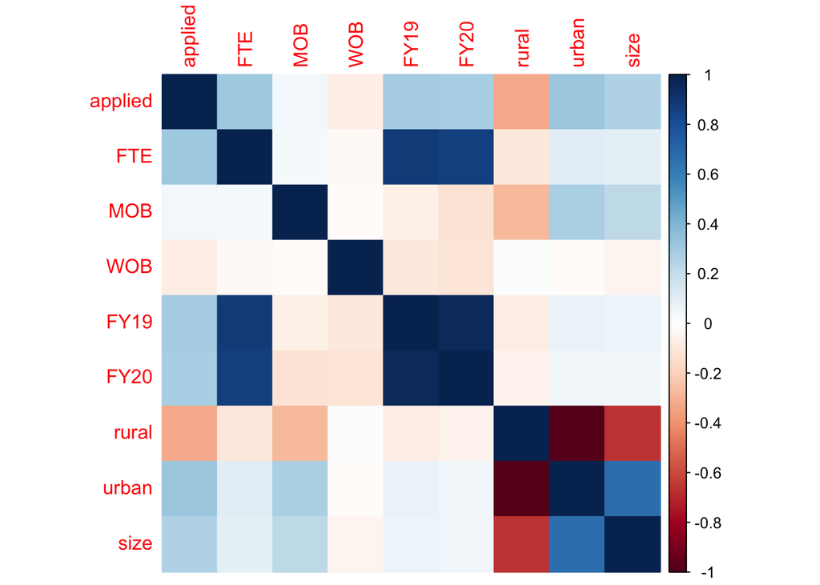

```r
# Plot the correlation matrix
corrplot(corr_matrix, method = "color")
```

The values in the matrix range from -1 to 1, with values closer to -1 indicating a strong negative correlation, values closer to 1 indicating a strong positive correlation, and values closer to 0 indicating little or no correlation.

Variables that could cause issues of multicollinearity in logistic regression are: FTE and FY19 (correlation coefficient of 0.88), FTE and FY20 (correlation coefficient of 0.86), FY19 and FY20 (correlation coefficient of 0.97), and Rural and Urban (correlation coefficient of -1.00)

Including some of these variables in a logistic regression model could lead to multicollinearity issues.To avoid multicollinearity, it may be necessary to choose one of these highly correlated variables to include in the logistic regression model, or to combine them into a single variable. Alternatively, more advanced methods such as principal component analysis (PCA) or ridge regression could be used to handle multicollinearity issues.

```r
library(stargazer)
# Fit a logistic regression model with applied as the outcome
# changing predictors to handle multicollinearity issues

# Fit logistic models
model1 <- glm(applied ~ FTE + MOB + WOB, data = clean_data,
              family = "binomial")
model2 <- glm(applied ~ FY19 + MOB + WOB, data = clean_data,
              family = "binomial")
model3 <- glm(applied ~ FY20 + MOB + WOB, data = clean_data,
              family = "binomial")

# Print the results side by side
stargazer(model1, model2, model3, type = "text",
          header = FALSE,
          title = "Logistic Regression Results",
          column.labels = c("Model 1", "Model 2", "Model 3"),
          dep.var.labels = c("Applied"),
          align = TRUE,
          star.cutoffs = c(0.05, 0.01, 0.001),
          model.numbers = FALSE)
```

```
##
## Logistic Regression Results
## ==================================================
##                         Dependent variable:
##                   --------------------------------
##                               Applied
##                    Model 1    Model 2    Model 3
## --------------------------------------------------
## FTE                0.022***
##                    (0.001)
##
## FY19                         0.00000***
##                              (0.00000)
##
## FY20                                    0.00000***
##                                         (0.00000)
##
## MOB                0.156**    0.281***   0.353***
##                    (0.059)    (0.058)    (0.059)
##
## WOB               -0.360***  -0.250***   -0.203**
##                    (0.070)    (0.070)    (0.069)
##
## Constant          -1.075***  -0.483***  -0.514***
##                    (0.074)    (0.055)    (0.056)
##
## --------------------------------------------------
## Observations        5,331      5,331      5,331
## Log Likelihood    -3,350.269 -3,363.980 -3,371.961
## Akaike Inf. Crit. 6,708.537  6,735.961  6,751.921
## ==================================================
## Note:                *p<0.05; **p<0.01; ***p<0.001
```

Interpreting results of logistic regression models:

- applied: a binary indicator for whether a small business owner applied for aid;
  - FTE: number of full-time equivalent employees;
  - MOB: indicator for whether the business is minority-owned;
  - WOB: indicator for whether the business is woman-owned;
  - FY19: reported revenue in the 2019 fiscal year;
  - FY20: reported revenue in the 2020 fiscal year;
  - size: the population within the zip code;
  - urban: indicator of urban status of the zip code;
  - rural: indicator of rural status of the zip code.

For Model 1, FTE is statistically significant with a positive coefficient of 0.022 (p < 0.001), suggesting that a one-unit increase in FTE is associated with an increase in the odds of being applied.

For Model 2, FY19 is statistically significant with a positive coefficient of 0.00000 (p < 0.001), indicating that a one-unit increase in FY19 is associated with an increase in the odds of being applied.

For Model 3, FY20 is statistically significant with a positive coefficient of 0.00000 (p < 0.001), suggesting that a one-unit increase in FY20 is associated with an increase in the odds of being applied.

To compare the performance of these models, you can use the Akaike Information Criterion (AIC) or the Bayesian Information Criterion (BIC). Both of these metrics balance the goodness of fit with the complexity of the model.

In general, lower values of AIC or BIC indicate a better model fit. Based on the AIC scores reported in the added lines, Model 1 performed better than the other two models, as it has the lowest AIC value (6,708.54). This suggests that Model 1 has the best balance of goodness-of-fit and complexity among the three models. We will add more parameter values to this model to check if we can continue to improve model fit.

```r
# Fit logistic models
model1 <- glm(applied ~ FTE + MOB + WOB, data = clean_data,
              family = "binomial")
model4 <- glm(applied ~ FTE + MOB + WOB + rural, data = clean_data,
              family = "binomial")
model5 <- glm(applied ~ FTE + MOB + WOB + urban, data = clean_data,
              family = "binomial")
model6 <- glm(applied ~ FTE + MOB + WOB + size, data = clean_data,
              family = "binomial")


# Print the results side by side
stargazer(model1, model4, model5, model6, type = "text",
          header = FALSE,
          title = "Logistic Regression Results",
          column.labels = c("Model 1", "Model 4", "Model 5", "Model 6"),
          dep.var.labels = c("Applied"),
          align = TRUE,
          star.cutoffs = c(0.05, 0.01, 0.001),
          model.numbers = FALSE)
```

```
##
## Logistic Regression Results
## =============================================================
##                               Dependent variable:
##                   -------------------------------------------
##                                     Applied
##                    Model 1    Model 4    Model 5    Model 6
## -------------------------------------------------------------
## FTE                0.022***   0.023***   0.023***   0.023***
##                    (0.001)    (0.001)    (0.001)    (0.001)
##
## MOB                0.156**   -0.236***  -0.236***    -0.097
##                    (0.059)    (0.064)    (0.064)    (0.062)
##
## WOB               -0.360***  -0.376***  -0.376***  -0.333***
##                    (0.070)    (0.074)    (0.074)    (0.073)
##
## rural                        -2.208***
##                               (0.110)
##
## urban                                    2.208***
##                                          (0.110)
##
## size                                               0.0001***
##                                                    (0.00001)
##
## Constant          -1.075***  -0.602***  -2.810***  -2.034***
##                    (0.074)    (0.080)    (0.124)    (0.096)
##
## -------------------------------------------------------------
## Observations        5,331      5,331      5,331      5,331
## Log Likelihood    -3,350.269 -3,092.229 -3,092.229 -3,180.671
## Akaike Inf. Crit. 6,708.537  6,194.458  6,194.458  6,371.343
## =============================================================
## Note:                           *p<0.05; **p<0.01; ***p<0.001
```

Model 1: FTE and MOB were significant predictors of applied. For every one unit increase in FTE, the odds of applying increased by a factor of 1.02, holding all other variables constant. For every one unit increase in MOB, the odds of applying increased by a factor of 1.17, holding all other variables constant.

Model 4: In addition to FTE and MOB, the variable rural was included in the model and was statistically significant. Rural schools were associated with a decrease in the odds of applying by a factor of 9.10, holding all other variables constant.

Model 5: In addition to FTE and MOB, the variable urban was included in the model and was statistically significant. Urban schools were associated with an increase in the odds of applying by a factor of 9.10, holding all other variables constant.

Model 6: In addition to FTE, MOB, and the variable size was included in the model and was statistically significant. For every one unit increase in size, the odds of applying increased by a factor of 1.00.

Based on the AIC scores reported in the added lines, Model 4 & 5, which included information about the urban/rural status associated with a specific zip code,performed better than the other two models, as they have the lowest AIC values (6,194.45).

# 3) Decision Trees:

Decision trees can provide additional insights into the factors that differentiate between businesses that applied and those that did not apply. Decision trees can identify the most important variables for predicting the outcome variable and show how they interact with each other. Additionally, decision trees can handle non-linear relationships between the predictor variables and the outcome variable.

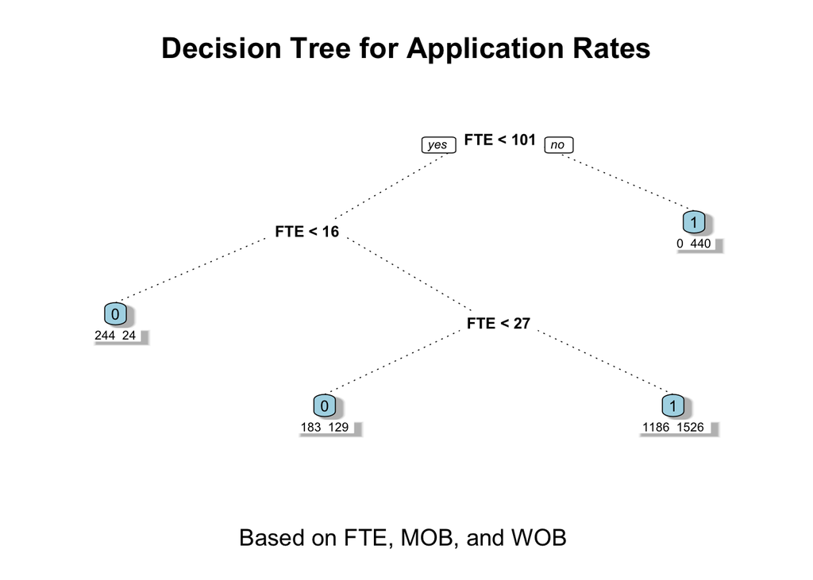

```r
# Load required packages
library(rpart)
library(rpart.plot)
library(caret)
# Set seed for reproducibility
set.seed(123)

# Split the data into training and testing sets
train_index <- createDataPartition(clean_data$applied_factor, p = 0.7,
                                   list = FALSE)
train_data <- clean_data[train_index, ]
test_data <- clean_data[-train_index, ]


# Note that the outcome variable applied needs to be converted to a factor
# before running the model. Also, the method = "class" argument specifies
# that we are running a classification tree, since the outcome variable
# is categorical.


# Build decision tree models
tree_model1 <- rpart(applied_factor ~ FTE + MOB + WOB,
                    data = train_data, method = "class")

tree_model2 <- rpart(applied_factor ~ FTE + MOB + WOB + rural + urban + size,
                    data = train_data, method = "class")


# Plot decision trees
prp(tree_model1, extra = 1, under = TRUE, cex = 0.8,
    branch.lty = 3, box.col = "lightblue", shadow.col = "gray",
    cex.main = 1.5, cex.sub = 1.2,
    main = "Decision Tree for Application Rates",
    sub = "Based on FTE, MOB, and WOB")
```

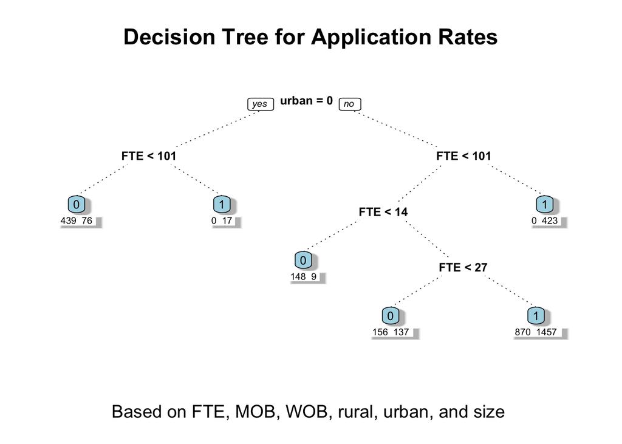

```r
prp(tree_model2, extra = 1, under = TRUE, cex = 0.8,
    branch.lty = 3, box.col = "lightblue", shadow.col = "gray",
    cex.main = 1.5, cex.sub = 1.2,
    main = "Decision Tree for Application Rates",
    sub = "Based on FTE, MOB, WOB, rural, urban, and size")
```

```r
# Predict on test data
test_pred1 <- predict(tree_model1, newdata = test_data, type = "class")
test_pred2 <- predict(tree_model2, newdata = test_data, type = "class")
```

Interpreting the results of a decision tree involves several steps:

1. The first step is to look at the tree structure itself, which shows the hierarchy of splits and the variable and cut-point used at each split. This can give you an idea of which variables are most important in predicting the outcome.
2. Next, you can look at the variable importance measures, which show how much each variable contributed to the model’s accuracy.
3. You can also examine the terminal nodes (i.e., the leaves of the tree) and the predicted class probabilities associated with each node. This can help you identify which combinations of predictor variables are associated with different levels of the outcome variable.
4. Finally, you can use the confusion matrix to evaluate the model’s overall performance, including its accuracy, sensitivity, specificity, and other metrics. This can help you determine how well the model is predicting the outcome of interest.

```r
# Print confusion matrix
print("Confusion Matrix for Tree Model 1:")
```

```
## [1] "Confusion Matrix for Tree Model 1:"
```

```r
confusionMatrix(test_pred1, test_data$applied_factor)
```

```
## Confusion Matrix and Statistics
##
##           Reference
## Prediction   0   1
##          0 174  53
##          1 517 855
##
##                Accuracy : 0.6435
##                  95% CI : (0.6195, 0.667)
##     No Information Rate : 0.5679
##     P-Value [Acc > NIR] : 4.203e-10
##
##                   Kappa : 0.2103
##
##  Mcnemar's Test P-Value : < 2.2e-16
##
##             Sensitivity : 0.2518
##             Specificity : 0.9416
##          Pos Pred Value : 0.7665
##          Neg Pred Value : 0.6232
##              Prevalence : 0.4321
##          Detection Rate : 0.1088
##    Detection Prevalence : 0.1420
##       Balanced Accuracy : 0.5967
##
##        'Positive' Class : 0
##
```

This confusion matrix shows the results of the decision tree model applied to the test data. The rows represent the predicted values and the columns represent the actual values. In this case, there are two classes: 0 and 1. The model correctly predicted 174 instances of class 0 and 855 instances of class 1. However, it incorrectly predicted 53 instances of class 1 as class 0 and 517 instances of class 0 as class 1.

The accuracy of the model is 0.6435, meaning it correctly predicted 64.35% of the test data. The kappa value is 0.2103, which indicates a fair agreement between the predicted and actual values. The sensitivity is 0.2518, meaning that the model correctly identified 25.18% of the true positives. The specificity is 0.9416, indicating that the model correctly identified 94.16% of the true negatives.

Overall, these results suggest that the decision tree model has some predictive power, but there is room for improvement.

```r
# Print confusion matrix
print("Confusion Matrix for Tree Model 2:")
```

```
## [1] "Confusion Matrix for Tree Model 2:"
```

```r
confusionMatrix(test_pred2, test_data$applied_factor)
```

```
## Confusion Matrix and Statistics
##
##           Reference
## Prediction   0   1
##          0 300  74
##          1 391 834
##
##                Accuracy : 0.7092
##                  95% CI : (0.6863, 0.7314)
##     No Information Rate : 0.5679
##     P-Value [Acc > NIR] : < 2.2e-16
##
##                   Kappa : 0.3731
##
##  Mcnemar's Test P-Value : < 2.2e-16
##
##             Sensitivity : 0.4342
##             Specificity : 0.9185
##          Pos Pred Value : 0.8021
##          Neg Pred Value : 0.6808
##              Prevalence : 0.4321
##          Detection Rate : 0.1876
##    Detection Prevalence : 0.2339
##       Balanced Accuracy : 0.6763
##
##        'Positive' Class : 0
##
```

The confusion matrix shows the predicted and actual class distribution, where class 0 and 1 are the reference and prediction labels, respectively. The model has classified 300 instances as class 0 correctly, and 834 instances as class 1 correctly, but it has also misclassified 74 instances of class 1 as class 0 and 391 instances of class 0 as class 1.

# Data Analysis (Increasing Application Rates):

Second, our partners would like to explore the possibility of a future randomized trial estimating the effect of mailers (e.g. informational brochures about the program sent to potential applicants) on application rates. They would like to be able to know whether the outreach program was effective at increasing application rates overall, and ideally whether it was effective for business owners who were least likely to apply in the initial round.

The agency partner is relying on our expertise to recommend whether a randomized trial that can answer these questions is feasible. They have told us that mailing costs are not a concern, as they have already decided to conduct mail outreach in some form. Your role is to advise whether or not an RCT that answers their questions seems sufficiently well-powered, and if so, how it should be designed.

To advise on whether or not an RCT that answers the partner’s questions seems sufficiently well-powered, we would need to consider a few factors, such as the effect size of interest, the sample size available for the trial, and the statistical power required to detect the effect size.

One way to determine the required sample size for a trial is to conduct a power analysis. This involves estimating the effect size that the trial aims to detect, choosing a statistical power level (such as 80% or 90%), and calculating the sample size required to achieve this power level. Once we have determined the required sample size, we can assess whether it is feasible given the resources available for the trial, including the mailing costs, staff time, and other logistical considerations.

In terms of trial design, a randomized controlled trial would be appropriate to answer the partner’s questions about the effectiveness of mailers, specially if we can utilize the already collected email addresses to send electronic information (e.g. informational brochures, etc.), in increasing application rates. The trial could randomly assign potential applicants to receive either a mailer or no mailer, and then compare the future application rates between the two groups. To assess whether the mailer was effective for business owners who were least likely to apply in the initial round, the trial could also stratify the randomization by some measure of the likelihood of applying, such as past business revenue or ownership type. This would allow for a subgroup analysis to determine whether the mailer was more effective for this group of business owners.

# Sample Power Analysis:

```r
# Load power analysis library
library(pwr)

# Set effect sizes and alphas to test
effect_sizes <- seq(0.2, 0.8, 0.1) # the effect sizes to detect
alphas <- seq(0.01, 0.1, 0.01) # significance level
powers <- seq(0.8, 0.99, 0.01) # desired statistical power

# Effect size is a measure of the strength or magnitude of the relationship
# between two variables or the difference between two groups.

# Because a larger effect size is easier to detect with a smaller sample size.
# The power analysis is sensitive to the effect size because the effect
# size determines the magnitude of the difference between the two groups,
# and thus the magnitude of the signal in the data.
# A larger effect size leads to a stronger signal and
# requires a smaller sample size to achieve a given level of power.


# Loop through effect sizes, alphas, and powers, and calculate sample size required
results <- data.frame()
for (effect_size in effect_sizes) {
  for (alpha in alphas) {
    for (power in powers) {
      n <- pwr.t.test(d = effect_size, sig.level = alpha, power = power)$n
      result <- data.frame(effect_size = effect_size, alpha = alpha, power = power, sample_size = round(n))
      results <- rbind(results, result)
    }
  }
}

# Find the minimum and maximum sample size
min_sample <- min(results$sample_size)
max_sample <- max(results$sample_size)

# Print the results
cat(paste0("Minimum sample size: ", min_sample, "\n"))
```

```
## Minimum sample size: 20
```

```r
cat(paste0("Maximum sample size: ", max_sample, "\n\n"))
```

```
## Maximum sample size: 1203
```

```r
cat("Parameters for minimum sample size:\n")
```

```
## Parameters for minimum sample size:
```

```r
min_row <- results[results$sample_size == min_sample, ]
print(min_row[, c("effect_size", "alpha", "power", "sample_size")])
```

```
##      effect_size alpha power sample_size
## 1381         0.8   0.1   0.8          20
```

```r
cat("\nParameters for maximum sample size:\n")
```

```
##
## Parameters for maximum sample size:
```

```r
max_row <- results[results$sample_size == max_sample, ]
print(max_row[, c("effect_size", "alpha", "power", "sample_size")])
```

```
##    effect_size alpha power sample_size
## 20         0.2  0.01  0.99        1203
```

The minimum and maximum sample sizes needed for the trial were determined to be 20 and 1203, respectively. The minimum sample size required would make it feasible to conduct the trial, while the maximum sample size could be used to ensure greater statistical power. Considering the number of different business and email addresses (if our partners would like to employ paperless mailing strategies) included in the data set; this number of participants could be easily achieved.

The parameters for the minimum sample size were an effect size of 0.8, an alpha of 0.1, and a power of 0.8. The parameters for the maximum sample size were an effect size of 0.2, an alpha of 0.01, and a power of 0.99.